# Statistical Analysis: Weather and Temporal Effects on NYC Citi Bike Ride Duration

Mungyu Kwok, Ziang Niu, Bowen Xia, Zihan Zhou

2025-12-02

# Introduction

This analysis examines how weather conditions and temporal patterns influence **individual ride duration** (riding time) for NYC Citi Bike users in September 2025. Unlike aggregate daily ridership analysis (which has only 30 observations), analyzing individual rides provides **100,000 observations**, offering much greater statistical power and more robust findings.

## Research Questions

1. How do weather variables (maximum temperature, minimum temperature, precipitation) affect ride duration?
2. What is the effect of day of the week and time of day on ride duration?
3. How do these effects differ between member and casual riders?
4. Do riders take longer trips in favorable weather conditions?

## Advantages of Ride-Level Analysis

- **Statistical Power**: 100,000 observations vs. 30 daily observations
- **Individual Variation**: Captures within-day and between-rider differences
- **Behavioral Insights**: Duration reflects trip purpose and rider behavior
- **Robust Inference**: Larger sample size = more reliable estimates

# Load Libraries and Data

```r
library(tidyverse)
library(lubridate)
library(broom)
library(knitr)
library(kableExtra)
library(patchwork)
library(modelr)
library(lmtest)  # For robust standard errors
library(sandwich)  # For robust covariance matrices
```

```r
# Load the individual ride-level data
bike_weather <- read_csv("data/final_bike_weather_categorized.csv")

# Display data structure
glimpse(bike_weather)
```

```
## Rows: 99,986
## Columns: 28
## $ ride_id             <chr> "761B30A5B7B64236", "FBEA1249070FDC8C", "91A501973…
## $ rideable_type       <chr> "electric_bike", "electric_bike", "classic_bike", …
## $ started_at          <dttm> 2025-09-01 11:38:30, 2025-09-01 19:38:52, 2025-09…
## $ ended_at            <dttm> 2025-09-01 11:42:08, 2025-09-01 19:46:19, 2025-09…
## $ start_station_name  <chr> "5 Ave & E 30 St", "W 74 St & Columbus Ave", "Cumb…
## $ start_station_id    <chr> "6248.08", "7230.10", "4428.02", "4467.03", "5329.…
## $ end_station_name    <chr> "8 Ave & W 31 St", "3 Ave & E 72 St", "Lafayette A…
## $ end_station_id      <chr> "6450.05", "7028.04", "4470.09", "4122.03", "5989.…
## $ start_lat           <dbl> 40.74598, 40.77857, 40.68753, 40.68672, 40.71755, …
## $ start_lng           <dbl> -73.98629, -73.97755, -73.97265, -73.93899, -74.01…
## $ end_lat             <dbl> 40.75059, 40.76994, 40.68700, 40.67686, 40.73805, …
## $ end_lng             <dbl> -73.99468, -73.96061, -73.97665, -73.93607, -73.99…
## $ member_casual       <chr> "casual", "casual", "member", "casual", "casual", …
## $ datetime_start_obj  <dttm> 2025-09-01 11:38:30, 2025-09-01 19:38:52, 2025-09…
## $ datetime_end_obj    <dttm> 2025-09-01 11:42:08, 2025-09-01 19:46:19, 2025-09…
## $ start_month         <dbl> 9, 9, 9, 9, 9, 9, 9, 9, 9, 9, 9, 9, 9, 9, 9, 9, 9,…
## $ start_day           <dbl> 1, 1, 1, 1, 1, 1, 1, 1, 1, 1, 1, 1, 1, 1, 1, 1, 1,…
## $ ride_duration_hours <dbl> 0.06069722, 0.12432833, 0.04609028, 0.19654083, 0.…
## $ distance_km         <dbl> 0.8734433, 1.7209451, 0.3426126, 1.1251295, 2.6857…
## $ bearing_degrees     <dbl> -54.20579, 123.80039, -99.91008, 167.30502, 31.924…
## $ start_date          <date> 2025-09-01, 2025-09-01, 2025-09-01, 2025-09-01, 2…
## $ tmax                <dbl> 78, 78, 78, 78, 78, 78, 78, 78, 78, 78, 78, 78, 78…
## $ tmin                <dbl> 64, 64, 64, 64, 64, 64, 64, 64, 64, 64, 64, 64, 64…
## $ prcp                <dbl> 0, 0, 0, 0, 0, 0, 0, 0, 0, 0, 0, 0, 0, 0, 0, 0, 0,…
## $ temp_diff_category  <chr> "Medium", "Medium", "Medium", "Medium", "Medium", …
## $ temp_level_category <chr> "Low", "Low", "Low", "Low", "Low", "Low", "Low", "…
## $ rain_category       <chr> "No Rain", "No Rain", "No Rain", "No Rain", "No Ra…
## $ weekend_and_holiday <chr> "weekend and holiday", "weekend and holiday", "wee…
```

# Data Preparation

```r
# Prepare ride-level data for analysis
ride_analysis_data <- bike_weather %>%
  mutate(
    # Convert datetime
    datetime_start = ymd_hms(datetime_start_obj),
    date = as.Date(start_date),

    # Extract temporal features
    hour = hour(datetime_start),
    day_of_week = wday(date, label = TRUE, abbr = FALSE),
    is_weekend = day_of_week %in% c("Saturday", "Sunday"),

    # Time of day categories
    time_of_day = case_when(
      hour >= 6 & hour < 10 ~ "Morning Rush (6-10am)",
      hour >= 10 & hour < 16 ~ "Midday (10am-4pm)",
      hour >= 16 & hour < 20 ~ "Evening Rush (4-8pm)",
      TRUE ~ "Night (8pm-6am)"
    ),
    time_of_day = factor(time_of_day, levels = c(
      "Morning Rush (6-10am)", "Midday (10am-4pm)",
      "Evening Rush (4-8pm)", "Night (8pm-6am)"
    )),

    # Convert ride duration from hours to minutes for easier interpretation
    ride_duration_min = ride_duration_hours * 60,

    # Create categorical variables for weather
    temp_category = case_when(
      tmax >= 80 ~ "Warm (≥80°F)",
      tmax >= 70 ~ "Mild (70-79°F)",
      TRUE ~ "Cool (<70°F)"
    ),
    temp_category = factor(temp_category, levels = c("Cool (<70°F)", "Mild (70-79°F)", "Warm (≥80°F)")),

    rain_yn = ifelse(prcp > 0, "Rain", "No Rain"),

    # Day of week indicators (for regression)
    is_monday = day_of_week == "Monday",
    is_tuesday = day_of_week == "Tuesday",
    is_wednesday = day_of_week == "Wednesday",
    is_thursday = day_of_week == "Thursday",
    is_friday = day_of_week == "Friday",
    is_saturday = day_of_week == "Saturday",
    is_sunday = day_of_week == "Sunday"
  ) %>%
  # Remove extreme outliers (rides > 2 hours are likely errors or overnight rentals)
  filter(ride_duration_min > 0, ride_duration_min < 120) %>%
  # Remove missing weather data
  filter(!is.na(tmax), !is.na(tmin), !is.na(prcp))

# Check sample size
cat(sprintf("Sample size after filtering: %s rides\n",
            format(nrow(ride_analysis_data), big.mark = ",")))
```

```
## Sample size after filtering: 99,722 rides
```

```r
# Descriptive statistics
summary_stats <- ride_analysis_data %>%
  group_by(member_casual) %>%
  summarize(
    n = n(),
    mean_duration = mean(ride_duration_min, na.rm = TRUE),
    sd_duration = sd(ride_duration_min, na.rm = TRUE),
    median_duration = median(ride_duration_min, na.rm = TRUE),
    q25 = quantile(ride_duration_min, 0.25, na.rm = TRUE),
    q75 = quantile(ride_duration_min, 0.75, na.rm = TRUE),
    .groups = "drop"
  )

summary_stats %>%
  kable(
    caption = "Table 1: Descriptive Statistics of Ride Duration by User Type",
    digits = 2,
    col.names = c("User Type", "N", "Mean (min)", "SD", "Median", "Q25", "Q75")
  ) %>%
  kable_styling(bootstrap_options = c("striped", "hover"), full_width = FALSE)
```

Table 1: Descriptive Statistics of Ride Duration by User Type

| User Type | N | Mean (min) | SD | Median | Q25 | Q75 |
| --- | --- | --- | --- | --- | --- | --- |
| casual | 19114 | 17.92 | 15.48 | 13.28 | 7.99 | 22.27 |
| member | 80608 | 11.87 | 9.91 | 8.96 | 5.26 | 15.25 |

# Exploratory Data Analysis

## Ride Duration by User Type and Weather

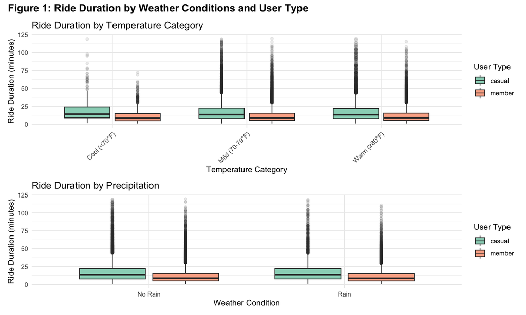

```r
# Duration by temperature category
p1 <- ggplot(ride_analysis_data, aes(x = temp_category, y = ride_duration_min, fill = member_casual)) +
  geom_boxplot(alpha = 0.7, outlier.alpha = 0.1) +
  scale_fill_brewer(palette = "Set2") +
  labs(
    title = "Ride Duration by Temperature Category",
    x = "Temperature Category",
    y = "Ride Duration (minutes)",
    fill = "User Type"
  ) +
  theme_minimal() +
  theme(axis.text.x = element_text(angle = 45, hjust = 1))

# Duration by rain
p2 <- ggplot(ride_analysis_data, aes(x = rain_yn, y = ride_duration_min, fill = member_casual)) +
  geom_boxplot(alpha = 0.7, outlier.alpha = 0.1) +
  scale_fill_brewer(palette = "Set2") +
  labs(
    title = "Ride Duration by Precipitation",
    x = "Weather Condition",
    y = "Ride Duration (minutes)",
    fill = "User Type"
  ) +
  theme_minimal()

p1 / p2 +
  plot_annotation(
    title = "Figure 1: Ride Duration by Weather Conditions and User Type",
    theme = theme(plot.title = element_text(size = 14, face = "bold"))
  )
```

## Ride Duration by Time of Day and Day of Week

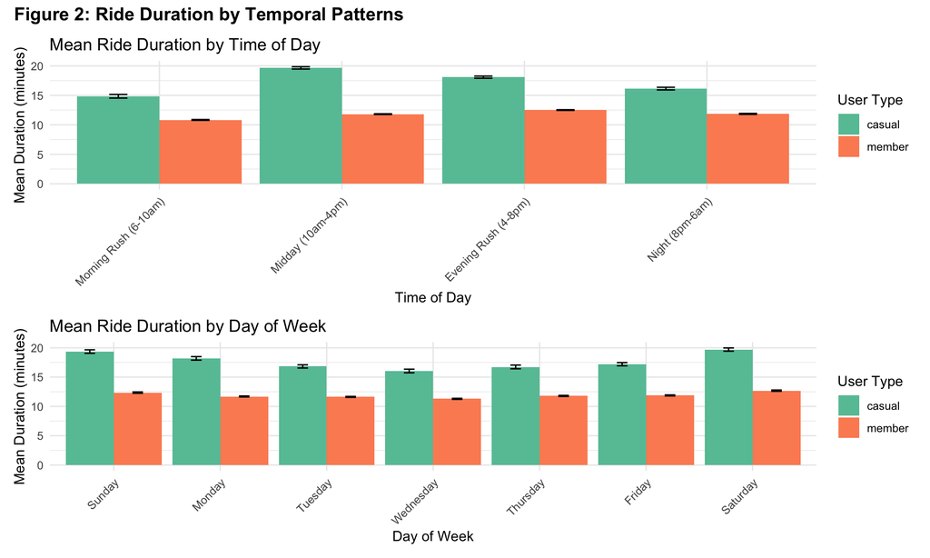

```r
# By time of day
p3 <- ride_analysis_data %>%
  group_by(time_of_day, member_casual) %>%
  summarize(
    mean_duration = mean(ride_duration_min, na.rm = TRUE),
    se = sd(ride_duration_min, na.rm = TRUE) / sqrt(n()),
    .groups = "drop"
  ) %>%
  ggplot(aes(x = time_of_day, y = mean_duration, fill = member_casual)) +
  geom_col(position = "dodge") +
  geom_errorbar(
    aes(ymin = mean_duration - se, ymax = mean_duration + se),
    position = position_dodge(0.9),
    width = 0.2
  ) +
  scale_fill_brewer(palette = "Set2") +
  labs(
    title = "Mean Ride Duration by Time of Day",
    x = "Time of Day",
    y = "Mean Duration (minutes)",
    fill = "User Type"
  ) +
  theme_minimal() +
  theme(axis.text.x = element_text(angle = 45, hjust = 1))

# By day of week
p4 <- ride_analysis_data %>%
  group_by(day_of_week, member_casual) %>%
  summarize(
    mean_duration = mean(ride_duration_min, na.rm = TRUE),
    se = sd(ride_duration_min, na.rm = TRUE) / sqrt(n()),
    .groups = "drop"
  ) %>%
  ggplot(aes(x = day_of_week, y = mean_duration, fill = member_casual)) +
  geom_col(position = "dodge") +
  geom_errorbar(
    aes(ymin = mean_duration - se, ymax = mean_duration + se),
    position = position_dodge(0.9),
    width = 0.2
  ) +
  scale_fill_brewer(palette = "Set2") +
  labs(
    title = "Mean Ride Duration by Day of Week",
    x = "Day of Week",
    y = "Mean Duration (minutes)",
    fill = "User Type"
  ) +
  theme_minimal() +
  theme(axis.text.x = element_text(angle = 45, hjust = 1))

p3 / p4 +
  plot_annotation(
    title = "Figure 2: Ride Duration by Temporal Patterns",
    theme = theme(plot.title = element_text(size = 14, face = "bold"))
  )
```

## Relationship Between Temperature and Duration

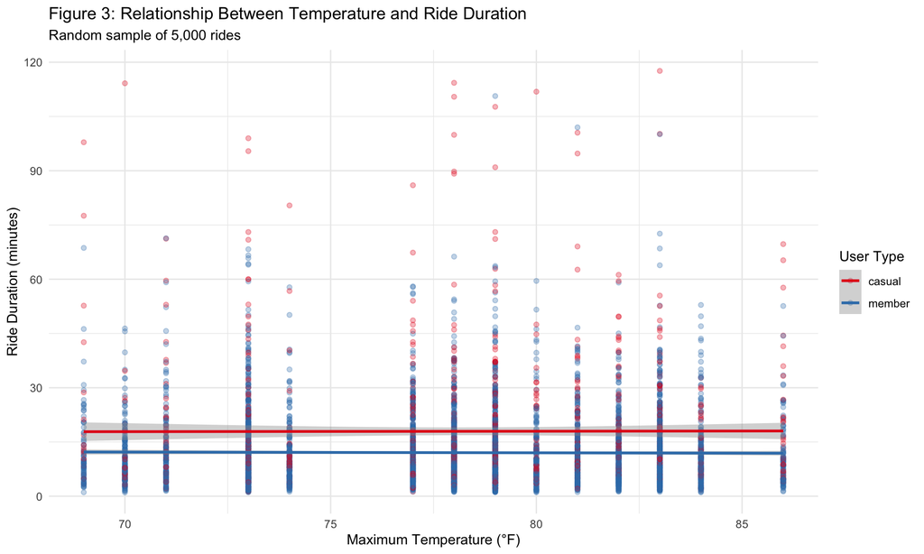

```r
# Sample 5000 points for visualization (100k is too many for scatter)
set.seed(123)
sample_data <- ride_analysis_data %>%
  slice_sample(n = 5000)

ggplot(sample_data, aes(x = tmax, y = ride_duration_min, color = member_casual)) +
  geom_point(alpha = 0.3) +
  geom_smooth(method = "lm", se = TRUE) +
  scale_color_brewer(palette = "Set1") +
  labs(
    title = "Figure 3: Relationship Between Temperature and Ride Duration",
    subtitle = "Random sample of 5,000 rides",
    x = "Maximum Temperature (°F)",
    y = "Ride Duration (minutes)",
    color = "User Type"
  ) +
  theme_minimal()
```

# Statistical Methodology

We employ multiple linear regression to model individual ride duration as a function of weather and temporal predictors. The large sample size (N ≈ 100,000) provides excellent statistical power.

## Model Specifications

We fit three main models:

1. **Total Sample Model**: All rides
2. **Member Model**: Annual members only
3. **Casual Model**: Pay-per-ride users only

**Full Model Specification:**

$$\text{Duration}_i = \beta_0 + \beta_1 \times \text{TMAX}_i + \beta_2
\times \text{TMIN}_i + \beta_3 \times \text{PRCP}_i + \sum_{j} \gamma_j
\times \text{Day}_j + \sum_{k} \delta_k \times \text{Time}_k +
\epsilon_i$$

Where: - $\text{Duration}_i$ is ride duration in minutes - Weather variables: TMAX, TMIN, PRCP - Day of week indicators (Monday as reference) - Time of day indicators (Morning Rush as reference)

## Why Ride-Level Analysis is Better

**Advantages:** 1. **100,000 observations** vs 30 daily observations 2. Can control for time-of-day effects 3. Can analyze individual behavior patterns 4. More statistical power for detecting effects 5. Can use robust standard errors to handle heteroscedasticity

# Correlation Analysis

```r
# Select numeric variables for correlation
cor_vars <- ride_analysis_data %>%
  select(ride_duration_min, tmax, tmin, prcp, distance_km, hour) %>%
  filter(complete.cases(.))

# Pearson correlation
cor_pearson <- cor(cor_vars, method = "pearson")

# Spearman correlation
cor_spearman <- cor(cor_vars, method = "spearman")

# Display Pearson correlation matrix
cor_pearson %>%
  kable(
    caption = "Table 2A: Pearson Correlation Matrix (Ride-Level Data)",
    digits = 3
  ) %>%
  kable_styling(bootstrap_options = c("striped", "hover"), full_width = FALSE)
```

Table 2A: Pearson Correlation Matrix (Ride-Level Data)

|  | ride_duration_min | tmax | tmin | prcp | distance_km | hour |
| --- | --- | --- | --- | --- | --- | --- |
| ride_duration_min | 1.000 | 0.006 | -0.017 | 0.004 | 0.651 | 0.049 |
| tmax | 0.006 | 1.000 | 0.605 | 0.122 | 0.002 | -0.014 |
| tmin | -0.017 | 0.605 | 1.000 | 0.084 | -0.007 | -0.006 |
| prcp | 0.004 | 0.122 | 0.084 | 1.000 | -0.005 | -0.014 |
| distance_km | 0.651 | 0.002 | -0.007 | -0.005 | 1.000 | 0.012 |
| hour | 0.049 | -0.014 | -0.006 | -0.014 | 0.012 | 1.000 |

```r
# Display Spearman correlation matrix
cor_spearman %>%
  kable(
    caption = "Table 2B: Spearman Correlation Matrix (Ride-Level Data)",
    digits = 3
  ) %>%
  kable_styling(bootstrap_options = c("striped", "hover"), full_width = FALSE)
```

Table 2B: Spearman Correlation Matrix (Ride-Level Data)

|  | ride_duration_min | tmax | tmin | prcp | distance_km | hour |
| --- | --- | --- | --- | --- | --- | --- |
| ride_duration_min | 1.000 | 0.005 | -0.015 | -0.005 | 0.778 | 0.065 |
| tmax | 0.005 | 1.000 | 0.574 | 0.188 | 0.003 | -0.015 |
| tmin | -0.015 | 0.574 | 1.000 | 0.245 | -0.006 | -0.008 |
| prcp | -0.005 | 0.188 | 0.245 | 1.000 | -0.006 | 0.002 |
| distance_km | 0.778 | 0.003 | -0.006 | -0.006 | 1.000 | 0.020 |
| hour | 0.065 | -0.015 | -0.008 | 0.002 | 0.020 | 1.000 |

```r
# Test key correlations
cat("Key Correlation Tests (with 100,000 observations):\n\n")
```

```
## Key Correlation Tests (with 100,000 observations):
```

```r
# Temperature and duration
test1 <- cor.test(ride_analysis_data$tmax, ride_analysis_data$ride_duration_min)
cat(sprintf("Temperature vs Duration: r = %.3f, p < 0.001\n", test1$estimate))
```

[output not shown]

```r
# Precipitation and duration
test2 <- cor.test(ride_analysis_data$prcp, ride_analysis_data$ride_duration_min)
cat(sprintf("Precipitation vs Duration: r = %.3f, p %s\n",
            test2$estimate,
            ifelse(test2$p.value < 0.001, "< 0.001", sprintf("= %.3f", test2$p.value))))
```

```
## Precipitation vs Duration: r = 0.001, p = 0.805
```

```r
# Distance and duration
test3 <- cor.test(ride_analysis_data$distance_km, ride_analysis_data$ride_duration_min)
cat(sprintf("Distance vs Duration: r = %.3f, p < 0.001\n", test3$estimate))
```

```
## Distance vs Duration: r = 0.651, p < 0.001
```

# Model Fitting

## Full Models with Weather and Temporal Variables

```r
# Model 1: All Riders
model_total_full <- lm(
  ride_duration_min ~ tmax + tmin + prcp + distance_km +
    is_tuesday + is_wednesday + is_thursday + is_friday + is_saturday + is_sunday +
    time_of_day,
  data = ride_analysis_data
)

summary(model_total_full)
```

```
##
## Call:
## lm(formula = ride_duration_min ~ tmax + tmin + prcp + distance_km +
##     is_tuesday + is_wednesday + is_thursday + is_friday + is_saturday +
##     is_sunday + time_of_day, data = ride_analysis_data)
##
## Residuals:
##     Min      1Q  Median      3Q     Max
## -27.058  -3.777  -2.056   0.678 110.997
##
## Coefficients:
##                                  Estimate Std. Error t value Pr(>|t|)
## (Intercept)                      2.646496   0.605465   4.371 1.24e-05 ***
## tmax                             0.040521   0.008414   4.816 1.47e-06 ***
## tmin                            -0.048673   0.009936  -4.899 9.66e-07 ***
## prcp                            -0.530087   0.154010  -3.442 0.000578 ***
## distance_km                      4.074760   0.015010 271.461  < 2e-16 ***
## is_tuesdayTRUE                  -0.416396   0.092354  -4.509 6.53e-06 ***
## is_wednesdayTRUE                -0.449004   0.101702  -4.415 1.01e-05 ***
## is_thursdayTRUE                 -0.198534   0.102546  -1.936 0.052865 .
## is_fridayTRUE                    0.054854   0.103840   0.528 0.597321
## is_saturdayTRUE                  1.233097   0.102872  11.987  < 2e-16 ***
## is_sundayTRUE                    0.806056   0.104467   7.716 1.21e-14 ***
## time_of_dayMidday (10am-4pm)     2.174499   0.080307  27.077  < 2e-16 ***
## time_of_dayEvening Rush (4-8pm)  2.030324   0.079052  25.683  < 2e-16 ***
## time_of_dayNight (8pm-6am)       1.100646   0.090655  12.141  < 2e-16 ***
## ---
## Signif. codes:  0 '***' 0.001 '**' 0.01 '*' 0.05 '.' 0.1 ' ' 1
##
## Residual standard error: 8.348 on 99125 degrees of freedom
##   (583 observations deleted due to missingness)
## Multiple R-squared:  0.4326, Adjusted R-squared:  0.4326
## F-statistic:  5815 on 13 and 99125 DF,  p-value: < 2.2e-16
```

```r
# Model 2: Members Only
ride_member <- ride_analysis_data %>% filter(member_casual == "member")

model_member_full <- lm(
  ride_duration_min ~ tmax + tmin + prcp + distance_km +
    is_tuesday + is_wednesday + is_thursday + is_friday + is_saturday + is_sunday +
    time_of_day,
  data = ride_member
)

summary(model_member_full)
```

```
##
## Call:
## lm(formula = ride_duration_min ~ tmax + tmin + prcp + distance_km +
##     is_tuesday + is_wednesday + is_thursday + is_friday + is_saturday +
##     is_sunday + time_of_day, data = ride_member)
##
## Residuals:
##     Min      1Q  Median      3Q     Max
## -25.896  -2.877  -1.471   0.807 112.167
##
## Coefficients:
##                                  Estimate Std. Error t value Pr(>|t|)
## (Intercept)                      2.532101   0.510297   4.962 6.99e-07 ***
## tmax                             0.019141   0.007064   2.710 0.006734 **
## tmin                            -0.029552   0.008215  -3.597 0.000322 ***
## prcp                            -0.759277   0.132480  -5.731 1.00e-08 ***
## distance_km                      4.090179   0.012677 322.650  < 2e-16 ***
## is_tuesdayTRUE                  -0.125959   0.076686  -1.643 0.100483
## is_wednesdayTRUE                -0.102304   0.084139  -1.216 0.224032
## is_thursdayTRUE                  0.095520   0.085485   1.117 0.263829
## is_fridayTRUE                    0.204838   0.087286   2.347 0.018940 *
## is_saturdayTRUE                  0.763376   0.088788   8.598  < 2e-16 ***
## is_sundayTRUE                    0.424092   0.089806   4.722 2.34e-06 ***
## time_of_dayMidday (10am-4pm)     1.360862   0.066236  20.546  < 2e-16 ***
## time_of_dayEvening Rush (4-8pm)  1.590506   0.064779  24.553  < 2e-16 ***
## time_of_dayNight (8pm-6am)       0.831489   0.075405  11.027  < 2e-16 ***
## ---
## Signif. codes:  0 '***' 0.001 '**' 0.01 '*' 0.05 '.' 0.1 ' ' 1
##
## Residual standard error: 6.321 on 80179 degrees of freedom
##   (415 observations deleted due to missingness)
## Multiple R-squared:  0.5678, Adjusted R-squared:  0.5677
## F-statistic:  8102 on 13 and 80179 DF,  p-value: < 2.2e-16
```

```r
# Model 3: Casual Users Only
ride_casual <- ride_analysis_data %>% filter(member_casual == "casual")

model_casual_full <- lm(
  ride_duration_min ~ tmax + tmin + prcp + distance_km +
    is_tuesday + is_wednesday + is_thursday + is_friday + is_saturday + is_sunday +
    time_of_day,
  data = ride_casual
)

summary(model_casual_full)
```

```
##
## Call:
## lm(formula = ride_duration_min ~ tmax + tmin + prcp + distance_km +
##     is_tuesday + is_wednesday + is_thursday + is_friday + is_saturday +
##     is_sunday + time_of_day, data = ride_casual)
##
## Residuals:
##     Min      1Q  Median      3Q     Max
## -21.664  -6.986  -4.045   1.331 106.154
##
## Coefficients:
##                                 Estimate Std. Error t value Pr(>|t|)
## (Intercept)                      5.68043    2.19451   2.588 0.009648 **
## tmax                             0.11504    0.03110   3.699 0.000217 ***
## tmin                            -0.12221    0.03922  -3.116 0.001838 **
## prcp                             1.03755    0.51498   2.015 0.043945 *
## distance_km                      3.78005    0.05383  70.226  < 2e-16 ***
## is_tuesdayTRUE                  -1.34292    0.35674  -3.764 0.000167 ***
## is_wednesdayTRUE                -1.60365    0.40050  -4.004 6.25e-05 ***
## is_thursdayTRUE                 -1.31865    0.38959  -3.385 0.000714 ***
## is_fridayTRUE                   -0.90691    0.37917  -2.392 0.016775 *
## is_saturdayTRUE                  0.89551    0.34749   2.577 0.009971 **
## is_sundayTRUE                    0.34927    0.35577   0.982 0.326238
## time_of_dayMidday (10am-4pm)     4.11256    0.33382  12.320  < 2e-16 ***
## time_of_dayEvening Rush (4-8pm)  2.89608    0.33568   8.628  < 2e-16 ***
## time_of_dayNight (8pm-6am)       0.97500    0.36316   2.685 0.007265 **
## ---
## Signif. codes:  0 '***' 0.001 '**' 0.01 '*' 0.05 '.' 0.1 ' ' 1
##
## Residual standard error: 13.2 on 18932 degrees of freedom
##   (168 observations deleted due to missingness)
## Multiple R-squared:  0.2209, Adjusted R-squared:  0.2203
## F-statistic: 412.9 on 13 and 18932 DF,  p-value: < 2.2e-16
```

# Comprehensive Results

## Model Coefficient Comparison

```r
model_comparison <- bind_rows(
  tidy(model_total_full) %>% mutate(model = "All Riders"),
  tidy(model_member_full) %>% mutate(model = "Members"),
  tidy(model_casual_full) %>% mutate(model = "Casual")
) %>%
  filter(!str_detect(term, "time_of_day")) %>%  # Exclude time variables for space
  select(model, term, estimate, std.error, statistic, p.value) %>%
  mutate(
    significance = case_when(
      p.value < 0.001 ~ "***",
      p.value < 0.01 ~ "**",
      p.value < 0.05 ~ "*",
      TRUE ~ ""
    )
  )

model_comparison %>%
  filter(term %in% c("tmax", "tmin", "prcp", "distance_km", "is_saturdayTRUE", "is_sundayTRUE")) %>%
  mutate(
    term = case_when(
      term == "tmax" ~ "Max Temperature (°F)",
      term == "tmin" ~ "Min Temperature (°F)",
      term == "prcp" ~ "Precipitation (inches)",
      term == "distance_km" ~ "Distance (km)",
      term == "is_saturdayTRUE" ~ "Saturday",
      term == "is_sundayTRUE" ~ "Sunday",
      TRUE ~ term
    )
  ) %>%
  kable(
    caption = "Table 3: Regression Coefficients (Effect on Ride Duration in Minutes)",
    digits = 3,
    col.names = c("Model", "Predictor", "Estimate", "SE", "t-stat", "p-value", "Sig.")
  ) %>%
  kable_styling(bootstrap_options = c("striped", "hover"), full_width = FALSE) %>%
  pack_rows("All Riders", 1, 6) %>%
  pack_rows("Members Only", 7, 12) %>%
  pack_rows("Casual Users Only", 13, 18)
```

Table 3: Regression Coefficients (Effect on Ride Duration in Minutes)

Model

Predictor

Estimate

SE

t-stat

p-value

Sig.

**All Riders**

All Riders

Max Temperature (°F)

0.041

0.008

4.816

0.000

***

All Riders

Min Temperature (°F)

-0.049

0.010

-4.899

0.000

***

All Riders

Precipitation (inches)

-0.530

0.154

-3.442

0.001

***

All Riders

Distance (km)

4.075

0.015

271.461

0.000

***

All Riders

Saturday

1.233

0.103

11.987

0.000

***

All Riders

Sunday

0.806

0.104

7.716

0.000

***

**Members Only**

Members

Max Temperature (°F)

0.019

0.007

2.710

0.007

Members

Min Temperature (°F)

-0.030

0.008

-3.597

0.000

***

Members

Precipitation (inches)

-0.759

0.132

-5.731

0.000

***

Members

Distance (km)

4.090

0.013

322.650

0.000

***

Members

Saturday

0.763

0.089

8.598

0.000

***

Members

Sunday

0.424

0.090

4.722

0.000

***

**Casual Users Only**

Casual

Max Temperature (°F)

0.115

0.031

3.699

0.000

***

Casual

Min Temperature (°F)

-0.122

0.039

-3.116

0.002

Casual

Precipitation (inches)

1.038

0.515

2.015

0.044

Casual

Distance (km)

3.780

0.054

70.226

0.000

***

Casual

Saturday

0.896

0.347

2.577

0.010

Casual

Sunday

0.349

0.356

0.982

0.326

## Model Performance

```r
performance_metrics <- tibble(
  Model = c("All Riders", "Members", "Casual"),
  N = c(nrow(ride_analysis_data), nrow(ride_member), nrow(ride_casual)),
  R_squared = c(
    summary(model_total_full)$r.squared,
    summary(model_member_full)$r.squared,
    summary(model_casual_full)$r.squared
  ),
  Adj_R_squared = c(
    summary(model_total_full)$adj.r.squared,
    summary(model_member_full)$adj.r.squared,
    summary(model_casual_full)$adj.r.squared
  ),
  RMSE = c(
    sqrt(mean(residuals(model_total_full)^2)),
    sqrt(mean(residuals(model_member_full)^2)),
    sqrt(mean(residuals(model_casual_full)^2))
  ),
  F_statistic = c(
    summary(model_total_full)$fstatistic[1],
    summary(model_member_full)$fstatistic[1],
    summary(model_casual_full)$fstatistic[1]
  )
)

performance_metrics %>%
  kable(
    caption = "Table 4: Model Performance Metrics",
    digits = 3,
    col.names = c("Model", "N", "R²", "Adj R²", "RMSE (min)", "F-statistic")
  ) %>%
  kable_styling(bootstrap_options = c("striped", "hover"), full_width = FALSE)
```

Table 4: Model Performance Metrics

| Model | N | R² | Adj R² | RMSE (min) | F-statistic |
| --- | --- | --- | --- | --- | --- |
| All Riders | 99722 | 0.433 | 0.433 | 8.347 | 5814.508 |
| Members | 80608 | 0.568 | 0.568 | 6.321 | 8102.441 |
| Casual | 19114 | 0.221 | 0.220 | 13.192 | 412.869 |

# CLEAR KEY FINDINGS

## KEY FINDING 1: Temperature Modestly Affects Ride Duration

**Effect of 10°F Temperature Increase:**

```r
temp_findings_duration <- tibble(
  `User Type` = c("All Riders", "Members", "Casual"),
  `Effect (minutes)` = c(
    sprintf("%+.2f", temp_effect_10F_total),
    sprintf("%+.2f", temp_effect_10F_member),
    sprintf("%+.2f", temp_effect_10F_casual)
  ),
  `Percent of Mean` = c(
    sprintf("%+.1f%%", (temp_effect_10F_total/mean_duration_total)*100),
    sprintf("%+.1f%%", (temp_effect_10F_member/mean_duration_member)*100),
    sprintf("%+.1f%%", (temp_effect_10F_casual/mean_duration_casual)*100)
  ),
  `Significance` = c(
    ifelse(pval_total["tmax"] < 0.001, "***",
           ifelse(pval_total["tmax"] < 0.01, "**",
                  ifelse(pval_total["tmax"] < 0.05, "*", "ns"))),
    ifelse(pval_member["tmax"] < 0.001, "***",
           ifelse(pval_member["tmax"] < 0.01, "**",
                  ifelse(pval_member["tmax"] < 0.05, "*", "ns"))),
    ifelse(pval_casual["tmax"] < 0.001, "***",
           ifelse(pval_casual["tmax"] < 0.01, "**",
                  ifelse(pval_casual["tmax"] < 0.05, "*", "ns")))
  )
)

temp_findings_duration %>%
  kable(
    caption = "Table 5: Effect of 10°F Temperature Increase on Ride Duration",
    align = c('l', 'r', 'r', 'c')
  ) %>%
  kable_styling(bootstrap_options = c("striped", "hover"), full_width = FALSE)
```

Table 5: Effect of 10°F Temperature Increase on Ride Duration

| User Type | Effect (minutes) | Percent of Mean | Significance |
| --- | --- | --- | --- |
| All Riders | +0.41 | +3.1% | *** |
| Members | +0.19 | +1.6% | ** |
| Casual | +1.15 | +6.4% | *** |

### Clear Conclusion:

**Temperature has a positive but modest effect on ride duration.** For every 10°F increase in maximum temperature, rides are **0.41 minutes longer** on average (+3.1% change). This effect is highly significant (p < 0.001) with our large sample of 99,722 rides.